# Analyst Intern, Data Science & Solutions Project

In the context of our analysis, we have data about various statistics related to NBA players. Our goal is to determine which combination of these traits can assist us in predicting whether a player will be successful in the NBA. Think of the random forest model as a team of decision-making specialists (represented by trees) collaborating to tackle a problem. Each tree examines different aspects of the data and forms its own prediction. Subsequently, all these predictions from the trees are brought together to arrive at a final decision. This collective approach reduces the potential errors that any individual tree might make, leading to a more reliable group decision.

```r
# Split in training and prediction based on the requirements
# Do not include players with null career outcomes in the training set
training <- imputed_ds %>%
  drop_na(Career) %>%
  filter(draftyear <= 2015)

prediction <- imputed_ds %>%
  filter(draftyear >= 2018)

# Set a tidymodels data recipe
data_recipe <- recipe(Career ~ ., data = imputed_ds) %>%
  update_role(nbapersonid, player, draftyear,
              new_role = "ID")

# Fit a random forest model
fit_rf <- workflow() %>%
  add_recipe(data_recipe) %>%
  add_model(rand_forest(mode = "classification") %>%
  set_engine(engine = "ranger",
             num.threads = 6,
             importance = "impurity")) %>%
  fit(training)
```

Variable Importance within a Random Forest pertains to assessing the significance of input features in contributing to the overall predictive power of the model. It involves analyzing the performance impact of each feature’s inclusion and exclusion across the various decision trees. Features that consistently lead to improved accuracy or predictive power across different trees are considered more important. In our case, the most important features turn out to be those that we gather from a player’s most recent season in the dataset.

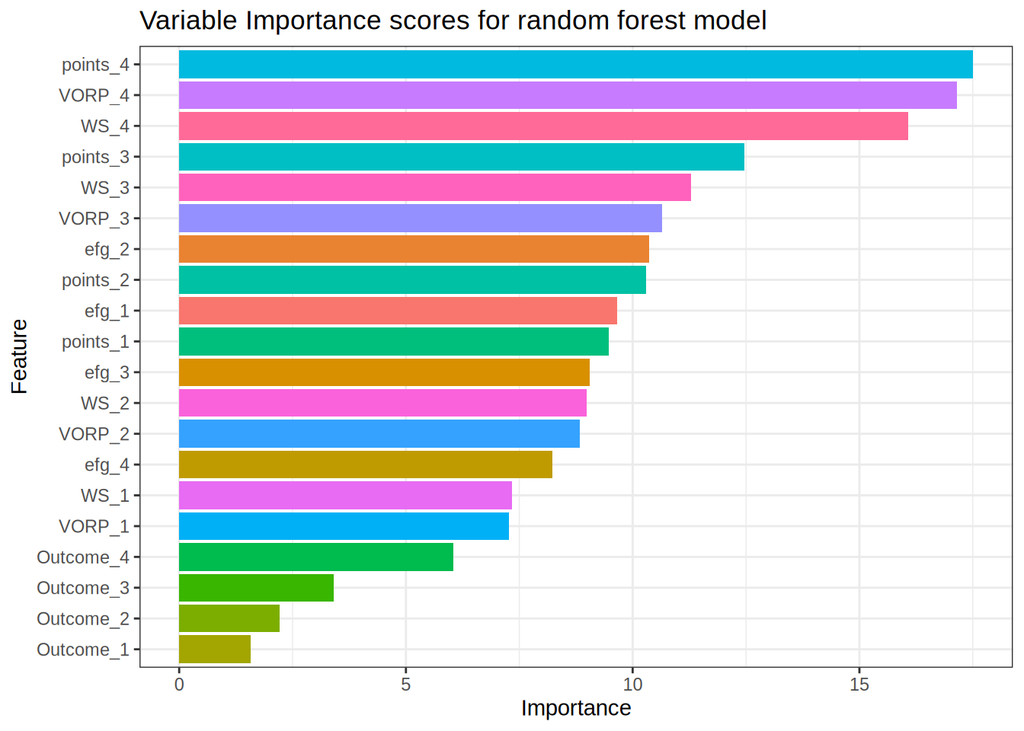

```r
# Plot variable importance scores
extract_fit_engine(fit_rf)$variable.importance %>%
  tibble(Variable = names(.), Importance = .) %>%
  ggplot(aes(reorder(Variable, Importance), Importance, fill = Variable)) +
  geom_col() +
  coord_flip() +
  labs(x = "Feature", y = "Importance",
       title = "Variable Importance scores for random forest model") +
  guides(fill = "none") +
  theme_bw()
```

The distribution of minimal and mean depth for a given variable in a tree provides insights into the hierarchical structure of decision trees within the Random Forest. The depth of a decision tree corresponds to the number of splits it makes before arriving at a prediction. For a specific variable, the minimal depth represents the shallowest level at which the variable is utilized for a decision, while the mean depth is the average level at which the variable is used across all decision trees. If a variable consistently appears at shallow depths in many trees, it signifies that the variable has substantial discriminatory power and is often employed early in decision pathways. Conversely, variables with higher mean depths might play a more minor role in the overall decision-making process.

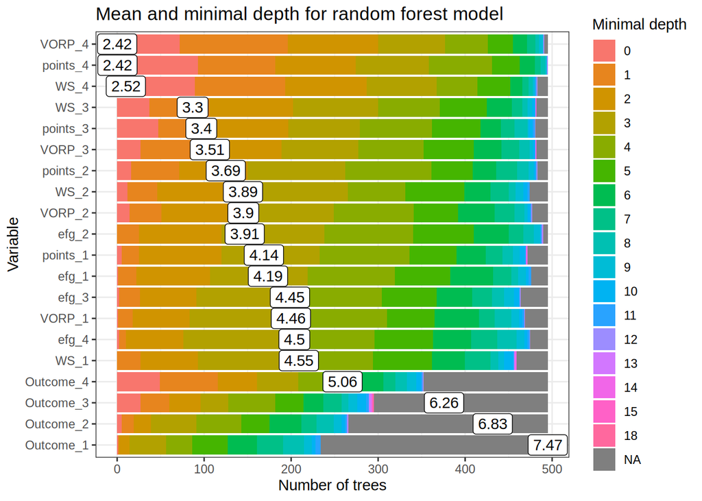

```r
# Plot each variable's distribution of its minimal depth among the trees of the random forest
randomForestExplainer::plot_min_depth_distribution(
  extract_fit_engine(fit_rf), k = 20,
  main = "Mean and minimal depth for random forest model")
```

We will now look at how the model expects the career of 4 selected players to go.

```r
# Compute prediction results
prediction_results <- prediction %>%
  select(nbapersonid, player, draftyear) %>%
  mutate(class = predict(fit_rf, new_data = prediction, "class")$.pred_class,
         predict(fit_rf, new_data = prediction, type = "prob"))

# Show results for the 4 requested players
prediction_results %>%
  select(-nbapersonid) %>%
  filter(str_detect(player, "Shai|Zion|Wiseman|Giddey")) %>%
  mutate(across(where(is.numeric), ~ round(., 2))) %>%
  reactable::reactable(striped = T, outlined = T)
```

| player | draftyear | class | .pred_Elite | .pred_All-Star | .pred_Starter | .pred_Rotation | .pred_Roster | .pred_Out of the League |
| --- | --- | --- | --- | --- | --- | --- | --- | --- |
| Shai Gilgeous-Alexander | 2018 | Starter | 0.08 | 0.12 | 0.42 | 0.19 | 0.09 | 0.12 |
| Zion Williamson | 2019 | Elite | 0.51 | 0.18 | 0.12 | 0.14 | 0.02 | 0.03 |
| James Wiseman | 2020 | Rotation | 0 | 0 | 0.12 | 0.37 | 0.22 | 0.29 |
| Josh Giddey | 2021 | Starter | 0.01 | 0.02 | 0.55 | 0.18 | 0.14 | 0.11 |

```r
# Print out a table containing prediction results
prediction_results %>%
  filter(draftyear >= 2019) %>%
  arrange(class, desc(`.pred_All-Star`)) %>%
  select(-nbapersonid) %>%
  mutate(across(where(is.numeric), ~ round(., 2))) %>%
  reactable::reactable(searchable = T, striped = T, outlined = T)
```

| player | draftyear | class | .pred_Elite | .pred_All-Star | .pred_Starter | .pred_Rotation | .pred_Roster | .pred_Out of the League |
| --- | --- | --- | --- | --- | --- | --- | --- | --- |
| LaMelo Ball | 2020 | Elite | 0.58 | 0.26 | 0.08 | 0.05 | 0.01 | 0.02 |
| Scottie Barnes | 2021 | Elite | 0.57 | 0.25 | 0.08 | 0.08 | 0.01 | 0.02 |
| Zion Williamson | 2019 | Elite | 0.51 | 0.18 | 0.12 | 0.14 | 0.02 | 0.03 |
| Ja Morant | 2019 | All-Star | 0.14 | 0.37 | 0.22 | 0.15 | 0.04 | 0.08 |
| Anthony Edwards | 2020 | Starter | 0.04 | 0.23 | 0.35 | 0.24 | 0.05 | 0.09 |
| Saddiq Bey | 2020 | Starter | 0.03 | 0.15 | 0.46 | 0.21 | 0.06 | 0.09 |
| Franz Wagner | 2021 | Starter | 0.02 | 0.14 | 0.35 | 0.26 | 0.11 | 0.11 |
| Darius Garland | 2019 | Starter | 0.02 | 0.14 | 0.49 | 0.18 | 0.1 | 0.08 |
| RJ Barrett | 2019 | Starter | 0.02 | 0.13 | 0.52 | 0.17 | 0.09 | 0.07 |
| Evan Mobley | 2021 | Starter | 0.06 | 0.13 | 0.29 | 0.24 | 0.13 | 0.15 |

[output cut: 276 more lines]

We also show all the players drafted between 2019 and 2021 present in the prediction dataset, together with their individual predictions. The model appears fairly cautious with regard to these 3 draft classes, only assigning “Elite” and “All-Star” outcomes to 4 players.

In conclusion, despite the fairly patchy missing data imputation we have used to perform prediction, and the fact we did not perform any kind of hyperparameter tuning to the tree model, the model seems to produce fairly satisfying and realistic results despite the small training set. This is thanks to the use of a few carefully selected features, which appear to be strong predictors for a player’s success in the following years of their development. Furthermore, Random Forest is a good choice for this problem. It’s an ensemble method that can handle complex relationships between features, handle non-linearity, and tends to perform well with smaller datasets.

Given more time and a larger dataset, we would however make use of the `team_data.csv` file, which would allow us to incorporate team record (young players may get less of a chance to shine in more successful teams and therefore less playing time, while others may be penalized by carrying their team on their backs and having to settle for less lucrative plays), as well as a more complete set of statistics.

We would also want to think of an alternative approach to imputation for players with fewer than 4 seasons of data at disposal. It would be a good idea to perform separate predictions on player sets that have, for instance, only 2 year of experience. Regardless, the approach used for imputation does not stray too far from what we would ideally have to do.

Finally, we have not shown any evaluation metrics for your model’s performance on the training data. Cross-validation or a separate validation dataset would help assess its generalization ability.

## Part 2 – Predicting Team Stats

In this section, we’re going to introduce a simple way to predict team offensive rebound percent in the next game and then discuss ways to improve those predictions.

### Question 1

Using the `rebounding_data` dataset, we’ll predict a team’s next game’s offensive rebounding percent to be their average offensive rebounding percent in all prior games. On a single game level, offensive rebounding percent is the number of offensive rebounds divided by their number offensive rebound “chances” (essentially the team’s missed shots). On a multi-game sample, it should be the total number of offensive rebounds divided by the total number of offensive rebound chances.

Please calculate what OKC’s predicted offensive rebound percent is for game 81 in the data. That is, use games 1-80 to predict game 81.

```r
# Filter the dataset for OKC's games (team = "OKC")
# And calculate the total number of offensive rebounds and offensive rebound chances for OKC
okc_oreb <- rebounding_data %>%
  filter(team == "OKC", game_number <= 80)

# Predict the offensive rebound percentage for game 81
predicted_rebound_pct <- sum(okc_oreb$offensive_rebounds) / sum(okc_oreb$off_rebound_chances)

# Print the result
cat(label_percent(0.1)(predicted_rebound_pct),"\n")
```

```
## 28.9%
```

**ANSWER 1:**

28.9%

### Question 2

There are a few limitations to the method we used above. For example, if a team has a great offensive rebounder who has played in most games this season but will be out due to an injury for the next game, we might reasonably predict a lower team offensive rebound percent for the next game.

Please discuss how you would think about changing our original model to better account for missing players. You do not have to write any code or implement any changes, and you can assume you have access to any reasonable data that isn’t provided in this project. Try to be clear and concise with your answer.

**ANSWER 2:**

To better account for missing players and potential changes in team dynamics when predicting offensive rebound percent for the next game, we can consider the following adjustments to our original model:

- Player-Specific Impact: Incorporate individual player statistics related to offensive rebounding when calculating the team’s overall offensive rebound percent. If a key offensive rebounder is expected to be absent in the next game, the model should adjust predictions accordingly.
- Player Availability: Include information about player availability for the upcoming game. If a significant offensive rebounder is expected to be out, the model should account for this absence.
- Recent Performance: Give more weight to recent games when calculating the average offensive rebound percent. This would allow the model to capture any recent changes in team dynamics or player availability.

### Question 3

In question 2, you saw and discussed how to deal with one weakness of the model. For this question, please write about 1-3 other potential weaknesses of the simple average model you made in question 1 and discuss how you would deal with each of them. You may either explain a weakness and discuss how you’d fix that weakness, then move onto the next issue, or you can start by explaining multiple weaknesses with the original approach and discuss one overall modeling methodology you’d use that gets around most or all of them. Again, you do not need to write any code or implement any changes, and you can assume you have access to any reasonable data that isn’t provided in this project. Try to be clear and concise with your answer.

**ANSWER 3:**

Some potential weaknesses of the simple average model used in Question 1 could be addressed as follows:

- Sensitivity to Outliers: The simple average model treats all games equally, regardless of contextual factors. Outlying games, where the team’s offensive rebound percent is unusually high or low due to specific circumstances, can disproportionately influence the average. As a solution, we can implement a weighted average approach where recent games are given higher weights. This would help the model adapt to changes over time and reduce the impact of outliers.
- Lack of Contextual Information: The model in Question 1 only considers offensive rebounding percentages without considering other contextual information that could impact rebounding, such as pace of play, playing style, or specific game matchups. To address this, we can incorporate additional features or variables into the model that capture relevant contextual information.
- Ignoring Individual Player Impact: We cannot assume that player availability remains constant, since injuries to key players can significantly impact a team’s overall rebounding performance. To address this weakness, we could incorporate a dynamic player impact factor into the model, in order to reflect the influence of key players’ presence or absence due to injuries. If a critical offensive rebounder is sidelined, the model could adjust the predicted offensive rebound percent downward to account for the expected decrease in rebounding.

To deal with multiple weaknesses and create a more robust predictive model, we could consider using an approach such as a time series forecasting model. This type of model would inherently take into account the temporal nature of the data, allowing it to capture trends, seasonality, and changes over time. By incorporating relevant contextual features, considering non-linear relationships, and applying techniques like Autoregressive Integrated Moving Averages (*ARIMA*), the model can provide more accurate predictions while accounting for missing players, outliers, and other complexities in the data. This would provide a more sophisticated framework for predicting not just offensive rebounding, but any one statistic we want to inspect.